[figure not shown]

```r
library(lubridate)
```

# **DateTimes**

A **date-time** is a point on the timeline stored as the number of sections since `1970-01-01 00:00:00 UTC`

```r
as_datetime(1511870400)
```

```
[1] "2017-11-28 12:00:00 UTC"
```

A **date** is a point on the timeline stored as the number of days since `1970-01-01`

```r
as_date(17498)
```

```
[1] "2017-11-28"
```

A **time** is a point on the timeline stored as the number of seconds since `00:00:00`

```r
hms::as.hms(85)
```

```
00:01:25
```

# **Creating**

### *Setting Current*

Using the base `Sys`

```r
Sys.time()
```

```
[1] "2019-09-20 19:46:44 EDT"
```

```r
Sys.Date()
```

```
[1] "2019-09-20"
```

Using `lubridate`

```r
now()
```

```
[1] "2019-09-20 19:46:44 EDT"
```

```r
today()
```

```
[1] "2019-09-20"
```

### *Parsing*

Just specify the order or the components in the function. For example, `08/07/06` could be:

- Aug 7, 2006
- Jul 8, 2006
- Jul 6, 2008
- Jun 7, 2008?

```r
ymd("08/07/06")
```

```
[1] "2008-07-06"
```

```r
ydm("08/07/06")
```

```
[1] "2008-06-07"
```

```r
dmy("08/07/06")
```

```
[1] "2006-07-08"
```

```r
mdy("08/07/06")
```

```
[1] "2006-08-07"
```

It also works for more complicated renderings like “The 4th of July, 2018”

```r
dmy("The 4th of July, 2018")
```

```
[1] "2018-07-04"
```

And for time

```r
mdy_hms("08/07/06 10:09:30")
```

```
[1] "2006-08-07 10:09:30 UTC"
```

For more complex strings, the format can be specified

- `%Y`: 4-digit year (1982)
- `%y`: 2-digit year (82)
- `%m`: 2-digit month (01)
- `%d`: 2-digit day of the month (13)
- `%A`: weekday (Wednesday)
- `%a`: abbreviated weekday (Wed)
- `%B`: month (January)
- `%b`: abbreviated month (Jan)

```r
as.Date("1982-01-13")
```

```
[1] "1982-01-13"
```

```r
as.Date("Jan-13-82", format = "%b-%d-%y")
```

```
[1] "1982-01-13"
```

```r
as.Date("13 January, 1982", format = "%d %B, %Y")
```

```
[1] "1982-01-13"
```

- `%H`: hours as a decimal number (00-23)
- `%I`: hours as a decimal number (01-12)
- `%M`: minutes as a decimal number
- `%S`: seconds as a decimal number
- `%T`: shorthand notation for the typical format %H:%M:%S
- `%p`: AM/PM indicator

```r
as.POSIXct("2012-5-12 14:23:08")
```

```
[1] "2012-05-12 14:23:08 EDT"
```

```r
as.POSIXct("May 12, '12 hours:14 minutes:23 seconds:08",
           format = "%B %d, '%y hours:%H minutes:%M seconds:%S")
```

```
[1] "2012-05-12 14:23:08 EDT"
```

This can also be used to reformat the entry

```r
Sys.Date()
```

```
[1] "2019-09-20"
```

```r
format(Sys.Date(), format = "%d %B, %Y")
```

```
[1] "20 September, 2019"
```

```r
format(Sys.Date(), format = "Today is a %A!")
```

```
[1] "Today is a Friday!"
```

# **Timezones**

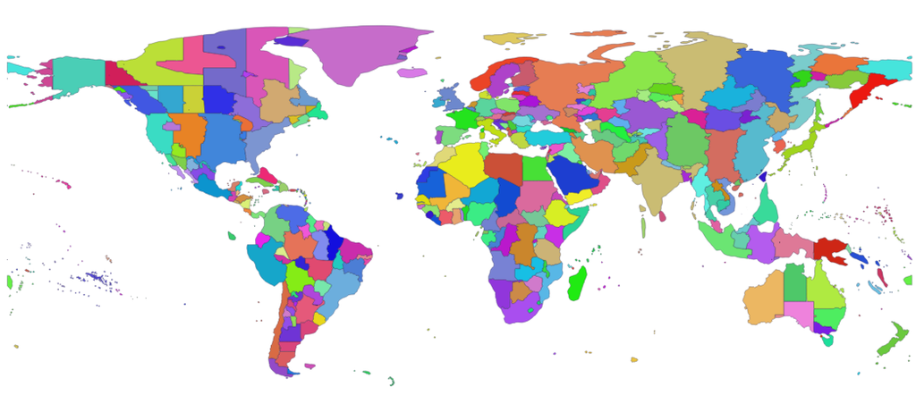

### **Recognized Zones**

```r
OlsonNames()
```

[output not shown]

[output cut: 284 more lines]

### **Current Zone**

#### *-System*

```r
Sys.timezone()
```

```
[1] "America/New_York"
```

#### *-Lubridate*

```r
tz(mystery_time)
```

```
[1] "Pacific/Truk"
```

### **Switching Zones**

```r
now()
```

```
[1] "2019-09-20 19:46:45 EDT"
```

```r
now(tzone = "America/Sitka")
```

```
[1] "2019-09-20 15:46:45 AKDT"
```

#### *- Correcting a mistake*

```r
mystery_time
```

```
[1] "2019-09-21 09:46:45 +10"
```

```r
force_tz(mystery_time, tzone = "America/New_York")
```

```
[1] "2019-09-21 09:46:45 EDT"
```

#### *- Converting*

```r
mystery_time
```

```
[1] "2019-09-21 09:46:45 +10"
```

```r
with_tz(mystery_time, tzone = "America/New_York")
```

```
[1] "2019-09-20 19:46:45 EDT"
```

# **Trimming**

```r
example_date <- now()
example_date
```

```
[1] "2019-09-20 19:46:45 EDT"
```

### **Extracting**

```r
date(example_date)
```

```
[1] "2019-09-20"
```

```r
year(example_date)
```

```
[1] 2019
```

```r
month(example_date, label = TRUE)
```

```
[1] Sep
12 Levels: Jan < Feb < Mar < Apr < May < Jun < Jul < Aug < Sep < ... < Dec
```

```r
day(example_date)
```

```
[1] 20
```

```r
wday(example_date, label = TRUE)
```

```
[1] Fri
Levels: Sun < Mon < Tue < Wed < Thu < Fri < Sat
```

```r
hour(example_date)
```

```
[1] 19
```

```r
minute(example_date)
```

```
[1] 46
```

```r
second(example_date)
```

```
[1] 45.31258
```

```r
week(example_date)
```

```
[1] 38
```

```r
quarter(example_date)
```

```
[1] 3
```

```r
dst(example_date) #Daylight savings in effect
```

```
[1] TRUE
```

```r
leap_year(example_date)
```

```
[1] FALSE
```

### **Rounding**

#### *- Backwards*

```r
floor_date(example_date, unit = "hour")
```

```
[1] "2019-09-20 19:00:00 EDT"
```

#### *- Forwards*

```r
ceiling_date(example_date, unit = "hour")
```

```
[1] "2019-09-20 20:00:00 EDT"
```

#### *- Closest*

```r
round_date(example_date, unit = "hour")
```

```
[1] "2019-09-20 20:00:00 EDT"
```

# **Comparisons**

### **Math**

Which is more important: the datetime in the real world or the length of time

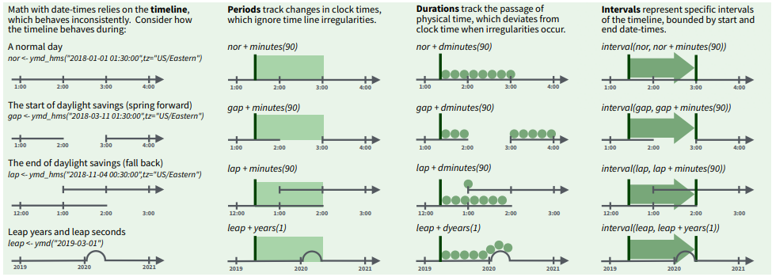

| . | Normal Day | Enter Daylight Savings | Exit Daylight Savings |
| --- | --- | --- | --- |
| . | *Normal* | *Spring forward an hour* | *Fall back an hour* |
| Example | 2018-01-01 **24**:00:00 | 2018-03-10 **24**:00:00 | 2018-11-03 **24**:00:00 |
| +3 Period `hours(3)` | 2018-01-01 **03**:00:00 | 2018-03-11 **03**:00:00 | 2018-11-04 **03**:00:00 |
| +3 Duration `dhours(3)` | 2018-01-01 **03**:00:00 | 2018-03-11 **04**:00:00 | 2018-11-04 **02**:00:00 |

| . | Normal Year | Leap Year |
| --- | --- | --- |
| . | *28 days in Feb* | *29 days in Feb* |
| Example | 2018-09-**20** | 2019-09-**20** |
| +1 Period `year(1)` | 2019-09-**20** | 2020-09-**20** |
| +1 Duration `dyear(1)` | 2019-09-**20** | 2020-09-**19** |

#### *- Periods*

```r
now() + years(1) + weeks(3) + days(4) + hours(5) + minutes(6) + seconds(7)
```

```
[1] "2020-10-16 00:52:53 EDT"
```

#### *- Durations*

```r
now() + dyears(1) + dweeks(3) + ddays(4) + dhours(5) + dminutes(6) + dseconds(7)
```

```
[1] "2020-10-15 00:52:53 EDT"
```

#### *- Months*

For months, there is only `months()` because there is nothing impacting a straight addition. However, there are imaginary dates that need to be dealt with:

```r
ymd("2019-1-31") + months(1)
```

```
[1] NA
```

```r
ymd("2019-1-31") %>% add_with_rollback(months(1))
```

```
[1] "2019-02-28"
```

```r
ymd("2019-1-31") %>% add_with_rollback(months(1), roll_to_first = TRUE)
```

```
[1] "2019-03-01"
```

```r
ymd("2019-1-31") + days(30)
```

```
[1] "2019-03-02"
```

### **Intervals**

#### *- Set*

```r
ryan <- interval(ymd("1990-11-04"), today())
ryan
```

```
[1] 1990-11-04 UTC--2019-09-20 UTC
```

#### *- Measure*

```r
int_length(ryan) %>% dseconds()
```

```
[1] "911260800s (~28.88 years)"
```

#### *- Modify*

```r
ryan
```

```
[1] 1990-11-04 UTC--2019-09-20 UTC
```

```r
int_start(ryan) <- ymd("1990-11-05")
int_end(ryan) <-ymd("2990-11-05")
ryan
```

```
[1] 1990-11-05 UTC--2990-11-05 UTC
```

```r
int_shift(ryan, days(5))
```

```
[1] 1990-11-09 19:00:00 EST--2990-11-09 20:00:00 EST
```

```r
int_shift(ryan, years(-10))
```

```
[1] 1980-11-04 19:00:00 EST--2980-11-04 20:00:00 EDT
```

#### *- Within*

```r
the_90s <- interval(ymd("1990-01-01"), ymd("1999-12-31"))

now() %within% the_90s
```

```
[1] FALSE
```

```r
ymd("1990-11-04") %within% the_90s
```

```
[1] TRUE
```

#### *- Overlap*

```r
the_1900s <- interval(ymd("1900-01-01"), ymd("1999-12-31"))

the_90s %within% the_1900s
```

```
[1] TRUE
```

```r
the_1900s %within% the_90s
```

```
[1] FALSE
```

```r
int_overlaps(the_90s,the_1900s)
```

```
[1] TRUE
```

```r
int_overlaps(the_1900s, the_90s)
```

```
[1] TRUE
```